# Progetto su dataset https://www.kaggle.com/datasets/leomartinelli/bullying-in-schools riguardante i fattori legati al bullismo nelle scuole

### MANUEL FASANELLA MAT.789775

```python
import pandas as pd
```

```python
dataset = pd.read_csv("Bullying_2018.csv",sep=';',index_col=0)
```

```python
dataset.columns
```

```
Index(['Bullied_on_school_property_in_past_12_months',
       'Bullied_not_on_school_property_in_past_12_months',
       'Cyber_bullied_in_past_12_months', 'Custom_Age', 'Sex',
       'Physically_attacked', 'Physical_fighting', 'Felt_lonely',
       'Close_friends', 'Miss_school_no_permission',
       'Other_students_kind_and_helpful', 'Parents_understand_problems',
       'Most_of_the_time_or_always_felt_lonely',
       'Missed_classes_or_school_without_permission', 'Were_underweight',
       'Were_overweight', 'Were_obese'],
      dtype='object')
```

```python
dataset.head()
```

| record | Bullied_on_school_property_in_past_12_months | Bullied_not_on_school_property_in_past_12_months | Cyber_bullied_in_past_12_months | Custom_Age | Sex | Physically_attacked | Physical_fighting | Felt_lonely | Close_friends | Miss_school_no_permission | Other_students_kind_and_helpful | Parents_understand_problems | Most_of_the_time_or_always_felt_lonely | Missed_classes_or_school_without_permission | Were_underweight | Were_overweight | Were_obese |
| --- | --- | --- | --- | --- | --- | --- | --- | --- | --- | --- | --- | --- | --- | --- | --- | --- | --- |
| 1 | Yes | Yes |  | 13 years old | Female | 0 times | 0 times | Always | 2 | 10 or more days | Never | Always | Yes | Yes |  |  |  |
| 2 | No | No | No | 13 years old | Female | 0 times | 0 times | Never | 3 or more | 0 days | Sometimes | Always | No | No |  |  |  |
| 3 | No | No | No | 14 years old | Male | 0 times | 0 times | Never | 3 or more | 0 days | Sometimes | Always | No | No | No | No | No |
| 4 | No | No | No | 16 years old | Male | 0 times | 2 or 3 times | Never | 3 or more | 0 days | Sometimes |  | No | No | No | No | No |
| 5 | No | No | No | 13 years old | Female | 0 times | 0 times | Rarely | 3 or more | 0 days | Most of the time | Most of the time | No | No |  |  |  |

```python
dataset.info()
```

```
<class 'pandas.core.frame.DataFrame'>
Index: 56981 entries, 1 to 57095
Data columns (total 17 columns):
 #   Column                                            Non-Null Count  Dtype
---  ------                                            --------------  -----
 0   Bullied_on_school_property_in_past_12_months      56981 non-null  object
 1   Bullied_not_on_school_property_in_past_12_months  56981 non-null  object
 2   Cyber_bullied_in_past_12_months                   56981 non-null  object
 3   Custom_Age                                        56981 non-null  object
 4   Sex                                               56981 non-null  object
 5   Physically_attacked                               56981 non-null  object
 6   Physical_fighting                                 56981 non-null  object
 7   Felt_lonely                                       56981 non-null  object
 8   Close_friends                                     56981 non-null  object
 9   Miss_school_no_permission                         56981 non-null  object
 10  Other_students_kind_and_helpful                   56981 non-null  object
 11  Parents_understand_problems                       56981 non-null  object
 12  Most_of_the_time_or_always_felt_lonely            56981 non-null  object
 13  Missed_classes_or_school_without_permission       56981 non-null  object
 14  Were_underweight                                  56981 non-null  object
 15  Were_overweight                                   56981 non-null  object
 16  Were_obese                                        56981 non-null  object
dtypes: object(17)
memory usage: 7.8+ MB
```

Procediamo prima con un analisi delle colonne del dataset, analizziamo i valori che le compongono e studiamo la situazione per i null

```python
dataset
```

| record | Bullied_on_school_property_in_past_12_months | Bullied_not_on_school_property_in_past_12_months | Cyber_bullied_in_past_12_months | Custom_Age | Sex | Physically_attacked | Physical_fighting | Felt_lonely | Close_friends | Miss_school_no_permission | Other_students_kind_and_helpful | Parents_understand_problems | Most_of_the_time_or_always_felt_lonely | Missed_classes_or_school_without_permission | Were_underweight | Were_overweight | Were_obese |
| --- | --- | --- | --- | --- | --- | --- | --- | --- | --- | --- | --- | --- | --- | --- | --- | --- | --- |
| 1 | Yes | Yes |  | 13 years old | Female | 0 times | 0 times | Always | 2 | 10 or more days | Never | Always | Yes | Yes |  |  |  |
| 2 | No | No | No | 13 years old | Female | 0 times | 0 times | Never | 3 or more | 0 days | Sometimes | Always | No | No |  |  |  |
| 3 | No | No | No | 14 years old | Male | 0 times | 0 times | Never | 3 or more | 0 days | Sometimes | Always | No | No | No | No | No |
| 4 | No | No | No | 16 years old | Male | 0 times | 2 or 3 times | Never | 3 or more | 0 days | Sometimes |  | No | No | No | No | No |
| 5 | No | No | No | 13 years old | Female | 0 times | 0 times | Rarely | 3 or more | 0 days | Most of the time | Most of the time | No | No |  |  |  |
| ... | ... | ... | ... | ... | ... | ... | ... | ... | ... | ... | ... | ... | ... | ... | ... | ... | ... |
| 57091 | No | Yes | No | 16 years old | Male | 0 times | 4 or 5 times | Sometimes | 3 or more | 0 days | Sometimes | Sometimes | No | No | No | Yes | No |
| 57092 | No | No | No | 16 years old | Male | 0 times | 0 times | Rarely | 1 | 0 days | Sometimes | Never | No | No |  |  |  |
| 57093 | No | No | No | 16 years old | Male | 0 times | 0 times | Sometimes | 3 or more | 0 days | Rarely | Sometimes | No | No |  |  |  |
| 57094 | No | Yes | No | 16 years old | Female | 0 times | 0 times | Sometimes | 2 | 0 days | Most of the time | Rarely | No | No |  |  |  |
| 57095 | No | Yes | Yes | 16 years old | Female | 0 times | 0 times | Always | 2 | 1 or 2 days | Rarely | Never | Yes | Yes | No | No | No |

56981 rows × 17 columns

```python
dataset.isnull().sum()
```

```
Bullied_on_school_property_in_past_12_months        0
Bullied_not_on_school_property_in_past_12_months    0
Cyber_bullied_in_past_12_months                     0
Custom_Age                                          0
Sex                                                 0
Physically_attacked                                 0
Physical_fighting                                   0
Felt_lonely                                         0
Close_friends                                       0
Miss_school_no_permission                           0
Other_students_kind_and_helpful                     0
Parents_understand_problems                         0
Most_of_the_time_or_always_felt_lonely              0
Missed_classes_or_school_without_permission         0
Were_underweight                                    0
Were_overweight                                     0
Were_obese                                          0
dtype: int64
```

## Per quanto riguarda la cella precedente ne deduciamo che, anche se si vedono alcune celle vuote, la somma dei valori nulli non è stata rilevata. Questo potrebbe essere dovuto ad alcuni spazi bianchi nei dati. Dobbiamo quindi pulirli

```python
import numpy as np
dataset.replace(r'^\s*$', np.nan, regex=True, inplace=True)
```

```python
dataset.head()
```

| record | Bullied_on_school_property_in_past_12_months | Bullied_not_on_school_property_in_past_12_months | Cyber_bullied_in_past_12_months | Custom_Age | Sex | Physically_attacked | Physical_fighting | Felt_lonely | Close_friends | Miss_school_no_permission | Other_students_kind_and_helpful | Parents_understand_problems | Most_of_the_time_or_always_felt_lonely | Missed_classes_or_school_without_permission | Were_underweight | Were_overweight | Were_obese |
| --- | --- | --- | --- | --- | --- | --- | --- | --- | --- | --- | --- | --- | --- | --- | --- | --- | --- |
| 1 | Yes | Yes | NaN | 13 years old | Female | 0 times | 0 times | Always | 2 | 10 or more days | Never | Always | Yes | Yes | NaN | NaN | NaN |
| 2 | No | No | No | 13 years old | Female | 0 times | 0 times | Never | 3 or more | 0 days | Sometimes | Always | No | No | NaN | NaN | NaN |
| 3 | No | No | No | 14 years old | Male | 0 times | 0 times | Never | 3 or more | 0 days | Sometimes | Always | No | No | No | No | No |
| 4 | No | No | No | 16 years old | Male | 0 times | 2 or 3 times | Never | 3 or more | 0 days | Sometimes | NaN | No | No | No | No | No |
| 5 | No | No | No | 13 years old | Female | 0 times | 0 times | Rarely | 3 or more | 0 days | Most of the time | Most of the time | No | No | NaN | NaN | NaN |

```python
dataset.isnull().sum()
```

```
Bullied_on_school_property_in_past_12_months         1239
Bullied_not_on_school_property_in_past_12_months      489
Cyber_bullied_in_past_12_months                       571
Custom_Age                                            108
Sex                                                   536
Physically_attacked                                   240
Physical_fighting                                     268
Felt_lonely                                           366
Close_friends                                        1076
Miss_school_no_permission                            1864
Other_students_kind_and_helpful                      1559
Parents_understand_problems                          2373
Most_of_the_time_or_always_felt_lonely                366
Missed_classes_or_school_without_permission          1864
Were_underweight                                    20929
Were_overweight                                     20929
Were_obese                                          20929
dtype: int64
```

```python
for col in dataset.columns:
    percent_missing_value = (dataset[col].isnull().sum()/dataset.shape[0]) * 100
    print("Percent of missing values for the column ", col, " is ", percent_missing_value)
```

```
Percent of missing values for the column  Bullied_on_school_property_in_past_12_months  is  2.174409013530826
Percent of missing values for the column  Bullied_not_on_school_property_in_past_12_months  is  0.8581807971078079
Percent of missing values for the column  Cyber_bullied_in_past_12_months  is  1.0020884154367244
Percent of missing values for the column  Custom_Age  is  0.1895368631649146
Percent of missing values for the column  Sex  is  0.9406644320036504
Percent of missing values for the column  Physically_attacked  is  0.42119302925536584
Percent of missing values for the column  Physical_fighting  is  0.4703322160018252
Percent of missing values for the column  Felt_lonely  is  0.6423193696144328
Percent of missing values for the column  Close_friends  is  1.8883487478282235
Percent of missing values for the column  Miss_school_no_permission  is  3.271265860550008
Percent of missing values for the column  Other_students_kind_and_helpful  is  2.7359997192046475
Percent of missing values for the column  Parents_understand_problems  is  4.164546076762429
Percent of missing values for the column  Most_of_the_time_or_always_felt_lonely  is  0.6423193696144328
Percent of missing values for the column  Missed_classes_or_school_without_permission  is  3.271265860550008
Percent of missing values for the column  Were_underweight  is  36.72978712202313
Percent of missing values for the column  Were_overweight  is  36.72978712202313
Percent of missing values for the column  Were_obese  is  36.72978712202313
```

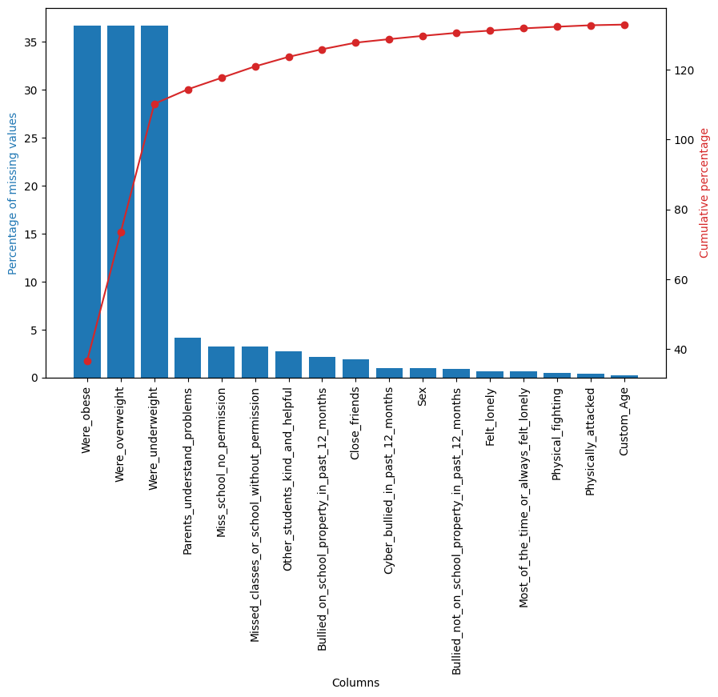

```python
from ipykernel import kernelapp as app
import matplotlib.pyplot as plt

# Calculate the percentage of missing values in each column
missing_perc = (dataset.isnull().sum() / len(dataset)) * 100

# Sort the columns by percentage of missing values in descending order
missing_perc_sorted = missing_perc.sort_values(ascending=False)

# Calculate the cumulative percentage of missing values
cumulative_perc = missing_perc_sorted.cumsum()

# Create a Pareto chart
fig, ax1 = plt.subplots(figsize=(10, 6))
ax1.bar(missing_perc_sorted.index, missing_perc_sorted.values, color='tab:blue')
ax1.set_xlabel('Columns')
ax1.set_ylabel('Percentage of missing values', color='tab:blue')
ax1.set_xticklabels(missing_perc_sorted.index, rotation=90)

# Add a secondary y-axis for the cumulative percentage
ax2 = ax1.twinx()
ax2.plot(missing_perc_sorted.index, cumulative_perc.values, color='tab:red', marker='o')
ax2.set_ylabel('Cumulative percentage', color='tab:red')


# Rotate the x-axis labels for better visibility
plt.xticks(rotation=90)

# Show the plot
plt.show()
```

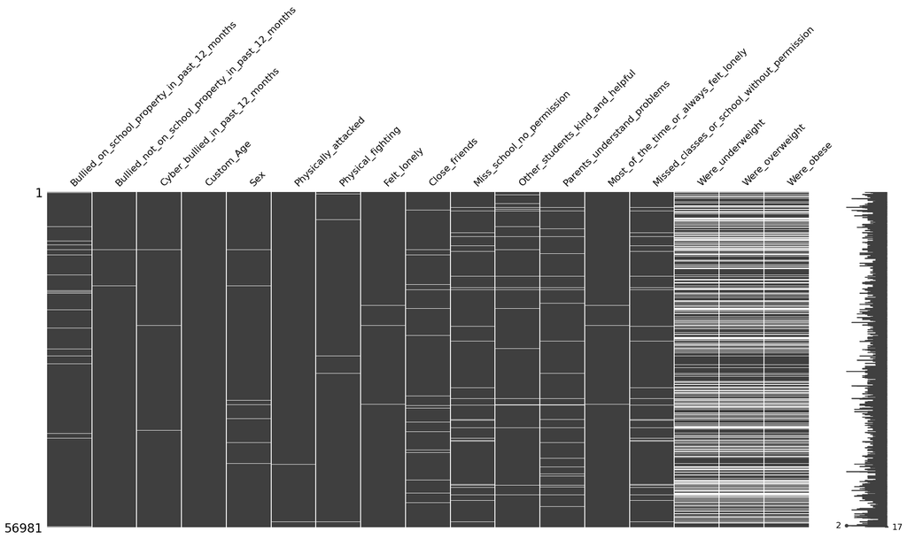

```python
import missingno as msno
# Visualize the null values
msno.matrix(dataset)
```

Come si può leggere per le ultime 3 colonne ovvero "Were_underweight", "Were_overweight" e "Were_obese" abbiamo una percentuale di null addirittura superiore al 35% il che non giustificherebbe una rimozione totale dei null. Si prosegue dunque facendo predizione sulle colonne con una percentuale di null molto significativa, mentre per le altre che hanno una percentuale molto bassa procediamo con la rimozione dei null

In quanto sono in percentuale minima, si decide di droppare i null delle colonne ad eccezione di quelle con un valore significativo di null per cui useremo qualche tecnica più sofisticata

```python
columns_to_keep = ['Were_underweight', 'Were_overweight','Were_obese']
dataset = dataset.dropna(subset=[col for col in dataset.columns if col not in columns_to_keep])
```

```python
for col in dataset.columns:
    percent_missing_value = (dataset[col].isnull().sum()/dataset.shape[0]) * 100
    print("Percent of missing values for the column ", col, " is ", percent_missing_value)
```

```
Percent of missing values for the column  Bullied_on_school_property_in_past_12_months  is  0.0
Percent of missing values for the column  Bullied_not_on_school_property_in_past_12_months  is  0.0
Percent of missing values for the column  Cyber_bullied_in_past_12_months  is  0.0
Percent of missing values for the column  Custom_Age  is  0.0
Percent of missing values for the column  Sex  is  0.0
Percent of missing values for the column  Physically_attacked  is  0.0
Percent of missing values for the column  Physical_fighting  is  0.0
Percent of missing values for the column  Felt_lonely  is  0.0
Percent of missing values for the column  Close_friends  is  0.0
Percent of missing values for the column  Miss_school_no_permission  is  0.0
Percent of missing values for the column  Other_students_kind_and_helpful  is  0.0
Percent of missing values for the column  Parents_understand_problems  is  0.0
Percent of missing values for the column  Most_of_the_time_or_always_felt_lonely  is  0.0
Percent of missing values for the column  Missed_classes_or_school_without_permission  is  0.0
Percent of missing values for the column  Were_underweight  is  35.10265200772353
Percent of missing values for the column  Were_overweight  is  35.10265200772353
Percent of missing values for the column  Were_obese  is  35.10265200772353
```

Rinomino le colonne con nomi troppo lunghi

```python
new_cols = {'Bullied_on_school_property_in_past_12_months': 'Bullied_in_school',
           'Bullied_not_on_school_property_in_past_12_months': 'Bullied_outside_school',
           'Cyber_bullied_in_past_12_months': 'Cyber_bullied'}

dataset = dataset.rename(columns=new_cols)
```

```python
new_dataset = dataset.dropna(subset=['Were_underweight', 'Were_overweight', 'Were_obese'])
new_dataset.to_csv('new_dataset.csv', index=False)
```

```python
for col in dataset.columns:
    percentage = dataset[col].value_counts(normalize=True) * 100
    print(percentage, "\n")
```

```
Bullied_in_school
No     78.973086
Yes    21.026914
Name: proportion, dtype: float64

Bullied_outside_school
No     78.776057
Yes    21.223943
Name: proportion, dtype: float64

Cyber_bullied
No     78.630256
Yes    21.369744
Name: proportion, dtype: float64

Custom_Age
14 years old               22.569650
15 years old               22.471135
16 years old               20.845648
13 years old               18.534500
17 years old               14.621508
18 years old or older       0.663987
12 years old                0.238405
11 years old or younger     0.055168
Name: proportion, dtype: float64

Sex
Female    52.66974
Male      47.33026
Name: proportion, dtype: float64

Physically_attacked
0 times             83.534303
1 time               8.952989
2 or 3 times         4.096229
12 or more times     1.288568
4 or 5 times         1.160500
6 or 7 times         0.478780
8 or 9 times         0.307365
10 or 11 times       0.181267
```

[output cut: 61 more lines]

```

Were_underweight
No     98.014451
Yes     1.985549
Name: proportion, dtype: float64

Were_overweight
No     70.523408
Yes    29.476592
Name: proportion, dtype: float64

Were_obese
No     92.756087
Yes     7.243913
Name: proportion, dtype: float64
```

Adesso effettuo una pulizia del dataset e controllo i valori per ogni colonna

```python
ord = {'Never': 0, 'Rarely': 1, 'Sometimes': 2, 'Most of the time': 3, 'Always': 4}
dataset.Felt_lonely = dataset.Felt_lonely.map(ord)
dataset.Other_students_kind_and_helpful = dataset.Other_students_kind_and_helpful.map(ord)
dataset.Parents_understand_problems = dataset.Parents_understand_problems.map(ord)

ord_2 = {"0 times": 0, "1 time": 1, "2 or 3 times" : 2, "4 or 5 times" : 3, "6 or 7 times" : 4, "8 or 9 times" : 5,
            "10 or 11 times" : 6, "12 or more times" : 7}
dataset.Physically_attacked = dataset.Physically_attacked.map(ord_2)
dataset.Physical_fighting = dataset.Physical_fighting.map(ord_2)

ord_3 = {"0": 0, "1": 1, "2" : 2, "3 or more" : 3}
dataset.Close_friends = dataset.Close_friends.map(ord_3)

ord_4 = {"0 days": 0, "1 or 2 days": 1, "3 to 5 days" : 2, "6 to 9 days" : 3, "10 or more days" : 4}
dataset.Miss_school_no_permission = dataset.Miss_school_no_permission.map(ord_4)

ord_5 = {'11 years old or younger' : 1, '12 years old' : 2, '13 years old' : 3, '14 years old' : 4, '15 years old' : 5,
       '16 years old' : 6, '17 years old' : 7, '18 years old or older' : 8}
dataset.Custom_Age = dataset.Custom_Age.map(ord_5)

columns = ['Felt_lonely', 'Other_students_kind_and_helpful', 'Parents_understand_problems', 'Physically_attacked',
           'Physical_fighting', 'Close_friends', 'Miss_school_no_permission', 'Custom_Age']

for col in columns:
    dataset[col] = dataset[col].astype(int)
```

```python
dataset.dtypes
```

```
Bullied_in_school                              object
Bullied_outside_school                         object
Cyber_bullied                                  object
Custom_Age                                      int32
Sex                                            object
Physically_attacked                             int32
Physical_fighting                               int32
Felt_lonely                                     int32
Close_friends                                   int32
Miss_school_no_permission                       int32
Other_students_kind_and_helpful                 int32
Parents_understand_problems                     int32
Most_of_the_time_or_always_felt_lonely         object
Missed_classes_or_school_without_permission    object
Were_underweight                               object
Were_overweight                                object
Were_obese                                     object
dtype: object
```

```python
for col in dataset.columns:
    print(col, dataset[col].unique(), '\n')
```

```
Bullied_in_school ['No' 'Yes']

Bullied_outside_school ['No' 'Yes']

Cyber_bullied ['No' 'Yes']

Custom_Age [3 4 2 5 1 6 7 8]

Sex ['Female' 'Male']

Physically_attacked [0 1 7 2 3 6 5 4]

Physical_fighting [0 1 2 3 4 5 6 7]

Felt_lonely [0 1 2 4 3]

Close_friends [3 0 2 1]

Miss_school_no_permission [0 3 2 4 1]

Other_students_kind_and_helpful [2 3 0 4 1]

Parents_understand_problems [4 3 0 2 1]

Most_of_the_time_or_always_felt_lonely ['No' 'Yes']

Missed_classes_or_school_without_permission ['No' 'Yes']

Were_underweight [nan 'No' 'Yes']

Were_overweight [nan 'No' 'Yes']

Were_obese [nan 'No' 'Yes']
```

```python
from sklearn.preprocessing import LabelEncoder

# encode categorical variables

categorical_columns = ['Bullied_in_school', 'Bullied_outside_school', 'Cyber_bullied', 'Sex', 'Most_of_the_time_or_always_felt_lonely',
                       'Missed_classes_or_school_without_permission']

le = LabelEncoder()

for col in categorical_columns:
    dataset[col] = le.fit_transform(dataset[col])
```

```python
for col in dataset.columns:
    print(dataset[col].value_counts(), '\n')
```

```
Bullied_in_school
0    40082
1    10672
Name: count, dtype: int64

Bullied_outside_school
0    39982
1    10772
Name: count, dtype: int64

Cyber_bullied
0    39908
1    10846
Name: count, dtype: int64

Custom_Age
4    11455
5    11405
6    10580
3     9407
7     7421
8      337
2      121
1       28
Name: count, dtype: int64

Sex
0    26732
1    24022
Name: count, dtype: int64

Physically_attacked
0    42397
1     4544
2     2079
7      654
3      589
4      243
5      156
6       92
```

[output cut: 61 more lines]

```

Were_underweight
No     32284
Yes      654
Name: count, dtype: int64

Were_overweight
No     23229
Yes     9709
Name: count, dtype: int64

Were_obese
No     30552
Yes     2386
Name: count, dtype: int64
```

```python
from sklearn.model_selection import train_test_split
from sklearn.ensemble import RandomForestClassifier

# Split the dataset into two parts: one with non-null values and another with null values
train_data = dataset.dropna(subset=['Were_underweight', 'Were_overweight', 'Were_obese'])
test_data = dataset[dataset['Were_underweight'].isnull() | dataset['Were_overweight'].isnull() | dataset['Were_obese'].isnull()]

# Separate the features and target columns
X_train = train_data.drop(['Were_underweight', 'Were_overweight', 'Were_obese'], axis=1)
y_train = train_data[['Were_underweight', 'Were_overweight', 'Were_obese']]
X_test = test_data.drop(['Were_underweight', 'Were_overweight', 'Were_obese'], axis=1)

# Train a classification model
model = RandomForestClassifier()
model.fit(X_train, y_train)

# Predict the target values for the dataset with null values
y_pred = model.predict(X_test)

# Replace the missing values in the target columns with the predicted values
dataset.loc[test_data.index, ['Were_underweight', 'Were_overweight', 'Were_obese']] = y_pred
```

```python
dataset['Were_obese'].value_counts()
```

```
Were_obese
No     48160
Yes     2594
Name: count, dtype: int64
```

```python
dataset
```

| record | Bullied_in_school | Bullied_outside_school | Cyber_bullied | Custom_Age | Sex | Physically_attacked | Physical_fighting | Felt_lonely | Close_friends | Miss_school_no_permission | Other_students_kind_and_helpful | Parents_understand_problems | Most_of_the_time_or_always_felt_lonely | Missed_classes_or_school_without_permission | Were_underweight | Were_overweight | Were_obese |
| --- | --- | --- | --- | --- | --- | --- | --- | --- | --- | --- | --- | --- | --- | --- | --- | --- | --- |
| 2 | 0 | 0 | 0 | 3 | 0 | 0 | 0 | 0 | 3 | 0 | 2 | 4 | 0 | 0 | No | No | No |
| 3 | 0 | 0 | 0 | 4 | 1 | 0 | 0 | 0 | 3 | 0 | 2 | 4 | 0 | 0 | No | No | No |
| 5 | 0 | 0 | 0 | 3 | 0 | 0 | 0 | 1 | 3 | 0 | 3 | 3 | 0 | 0 | No | No | No |
| 6 | 0 | 0 | 0 | 3 | 1 | 0 | 1 | 0 | 3 | 0 | 3 | 4 | 0 | 0 | No | No | No |
| 7 | 0 | 0 | 0 | 4 | 0 | 1 | 0 | 2 | 3 | 0 | 3 | 4 | 0 | 0 | No | No | No |
| ... | ... | ... | ... | ... | ... | ... | ... | ... | ... | ... | ... | ... | ... | ... | ... | ... | ... |
| 57091 | 0 | 1 | 0 | 6 | 1 | 0 | 3 | 2 | 3 | 0 | 2 | 2 | 0 | 0 | No | Yes | No |
| 57092 | 0 | 0 | 0 | 6 | 1 | 0 | 0 | 1 | 1 | 0 | 2 | 0 | 0 | 0 | Yes | No | No |
| 57093 | 0 | 0 | 0 | 6 | 1 | 0 | 0 | 2 | 3 | 0 | 1 | 2 | 0 | 0 | No | No | No |
| 57094 | 0 | 1 | 0 | 6 | 0 | 0 | 0 | 2 | 2 | 0 | 3 | 1 | 0 | 0 | No | No | No |
| 57095 | 0 | 1 | 1 | 6 | 0 | 0 | 0 | 4 | 2 | 1 | 1 | 0 | 1 | 1 | No | No | No |

50754 rows × 17 columns

```python
def one_hot_encode(df, column):
    encoded_df = pd.get_dummies(df[column], prefix=column, dtype=int)
    df = pd.concat([df, encoded_df], axis=1)
    df = df.drop(column, axis=1)  # Remove the original column
    return df

columns_ordinal = ['Felt_lonely', 'Other_students_kind_and_helpful', 'Parents_understand_problems', 'Physically_attacked',
           'Physical_fighting', 'Close_friends', 'Miss_school_no_permission', 'Custom_Age']

for col in dataset.columns:
    if col not in columns_ordinal:
        dataset = one_hot_encode(dataset, col)
```

```python
dataset
dataset.to_csv('Bullying_2018_cleaned.csv', sep=',', index=False)
```

```python
correlation_matrix = dataset.corr()
correlation_matrix
```

|  | Custom_Age | Physically_attacked | Physical_fighting | Felt_lonely | Close_friends | Miss_school_no_permission | Other_students_kind_and_helpful | Parents_understand_problems | Bullied_in_school_0 | Bullied_in_school_1 | ... | Most_of_the_time_or_always_felt_lonely_0 | Most_of_the_time_or_always_felt_lonely_1 | Missed_classes_or_school_without_permission_0 | Missed_classes_or_school_without_permission_1 | Were_underweight_No | Were_underweight_Yes | Were_overweight_No | Were_overweight_Yes | Were_obese_No | Were_obese_Yes |
| --- | --- | --- | --- | --- | --- | --- | --- | --- | --- | --- | --- | --- | --- | --- | --- | --- | --- | --- | --- | --- | --- |
| Custom_Age | 1.000000 | -0.013661 | -0.004033 | 0.096598 | -0.058885 | 0.120318 | 0.005354 | -0.049421 | 0.048453 | -0.048453 | ... | -0.044089 | 0.044089 | -0.124416 | 0.124416 | 0.005733 | -0.005733 | 0.069633 | -0.069633 | 0.008216 | -0.008216 |
| Physically_attacked | -0.013661 | 1.000000 | 0.311181 | 0.168788 | -0.046515 | 0.091649 | -0.089097 | -0.102704 | -0.161624 | 0.161624 | ... | -0.165207 | 0.165207 | -0.083014 | 0.083014 | -0.004757 | 0.004757 | -0.012199 | 0.012199 | -0.012009 | 0.012009 |
| Physical_fighting | -0.004033 | 0.311181 | 1.000000 | 0.049071 | 0.000603 | 0.146590 | -0.046637 | -0.066909 | -0.048682 | 0.048682 | ... | -0.053985 | 0.053985 | -0.126793 | 0.126793 | 0.002799 | -0.002799 | -0.019901 | 0.019901 | -0.013190 | 0.013190 |
| Felt_lonely | 0.096598 | 0.168788 | 0.049071 | 1.000000 | -0.191131 | 0.076733 | -0.180141 | -0.288747 | -0.204912 | 0.204912 | ... | -0.752007 | 0.752007 | -0.073129 | 0.073129 | 0.004781 | -0.004781 | 0.031102 | -0.031102 | 0.011173 | -0.011173 |
| Close_friends | -0.058885 | -0.046515 | 0.000603 | -0.191131 | 1.000000 | -0.020508 | 0.171505 | 0.124941 | 0.067147 | -0.067147 | ... | 0.180370 | -0.180370 | 0.023026 | -0.023026 | 0.003415 | -0.003415 | 0.010611 | -0.010611 | 0.006734 | -0.006734 |
| Miss_school_no_permission | 0.120318 | 0.091649 | 0.146590 | 0.076733 | -0.020508 | 1.000000 | -0.062508 | -0.090676 | -0.042970 | 0.042970 | ... | -0.067652 | 0.067652 | -0.825353 | 0.825353 | 0.007219 | -0.007219 | -0.006831 | 0.006831 | -0.008928 | 0.008928 |
| Other_students_kind_and_helpful | 0.005354 | -0.089097 | -0.046637 | -0.180141 | 0.171505 | -0.062508 | 1.000000 | 0.251008 | 0.131842 | -0.131842 | ... | 0.165695 | -0.165695 | 0.075437 | -0.075437 | 0.004229 | -0.004229 | 0.006544 | -0.006544 | 0.008638 | -0.008638 |
| Parents_understand_problems | -0.049421 | -0.102704 | -0.066909 | -0.288747 | 0.124941 | -0.090676 | 0.251008 | 1.000000 | 0.072039 | -0.072039 | ... | 0.243388 | -0.243388 | 0.100947 | -0.100947 | -0.002093 | 0.002093 | -0.013621 | 0.013621 | -0.013599 | 0.013599 |
| Bullied_in_school_0 | 0.048453 | -0.161624 | -0.048682 | -0.204912 | 0.067147 | -0.042970 | 0.131842 | 0.072039 | 1.000000 | -1.000000 | ... | 0.174508 | -0.174508 | 0.039704 | -0.039704 | 0.004831 | -0.004831 | 0.016334 | -0.016334 | 0.007149 | -0.007149 |
| Bullied_in_school_1 | -0.048453 | 0.161624 | 0.048682 | 0.204912 | -0.067147 | 0.042970 | -0.131842 | -0.072039 | -1.000000 | 1.000000 | ... | -0.174508 | 0.174508 | -0.039704 | 0.039704 | -0.004831 | 0.004831 | -0.016334 | 0.016334 | -0.007149 | 0.007149 |
| Bullied_outside_school_0 | -0.044861 | -0.175735 | -0.099771 | -0.205094 | 0.043752 | -0.077975 | 0.085256 | 0.096804 | 0.361481 | -0.361481 | ... | 0.172003 | -0.172003 | 0.075239 | -0.075239 | 0.002999 | -0.002999 | -0.010043 | 0.010043 | -0.008435 | 0.008435 |
| Bullied_outside_school_1 | 0.044861 | 0.175735 | 0.099771 | 0.205094 | -0.043752 | 0.077975 | -0.085256 | -0.096804 | -0.361481 | 0.361481 | ... | -0.172003 | 0.172003 | -0.075239 | 0.075239 | -0.002999 | 0.002999 | 0.010043 | -0.010043 | 0.008435 | -0.008435 |
| Cyber_bullied_0 | -0.039909 | -0.140126 | -0.076251 | -0.232180 | 0.051059 | -0.076104 | 0.083984 | 0.092597 | 0.279244 | -0.279244 | ... | 0.186931 | -0.186931 | 0.074983 | -0.074983 | -0.004081 | 0.004081 | -0.016067 | 0.016067 | -0.010331 | 0.010331 |
| Cyber_bullied_1 | 0.039909 | 0.140126 | 0.076251 | 0.232180 | -0.051059 | 0.076104 | -0.083984 | -0.092597 | -0.279244 | 0.279244 | ... | -0.186931 | 0.186931 | -0.074983 | 0.074983 | 0.004081 | -0.004081 | 0.016067 | -0.016067 | 0.010331 | -0.010331 |
| Sex_0 | -0.010127 | -0.037807 | -0.165322 | 0.269022 | -0.054767 | -0.031014 | -0.031592 | -0.042181 | -0.057918 | 0.057918 | ... | -0.172953 | 0.172953 | 0.040583 | -0.040583 | 0.020094 | -0.020094 | 0.094287 | -0.094287 | 0.055058 | -0.055058 |
| Sex_1 | 0.010127 | 0.037807 | 0.165322 | -0.269022 | 0.054767 | 0.031014 | 0.031592 | 0.042181 | 0.057918 | -0.057918 | ... | 0.172953 | -0.172953 | -0.040583 | 0.040583 | -0.020094 | 0.020094 | -0.094287 | 0.094287 | -0.055058 | 0.055058 |
| Most_of_the_time_or_always_felt_lonely_0 | -0.044089 | -0.165207 | -0.053985 | -0.752007 | 0.180370 | -0.067652 | 0.165695 | 0.243388 | 0.174508 | -0.174508 | ... | 1.000000 | -1.000000 | 0.059263 | -0.059263 | 0.006539 | -0.006539 | -0.018025 | 0.018025 | -0.003988 | 0.003988 |
| Most_of_the_time_or_always_felt_lonely_1 | 0.044089 | 0.165207 | 0.053985 | 0.752007 | -0.180370 | 0.067652 | -0.165695 | -0.243388 | -0.174508 | 0.174508 | ... | -1.000000 | 1.000000 | -0.059263 | 0.059263 | -0.006539 | 0.006539 | 0.018025 | -0.018025 | 0.003988 | -0.003988 |
| Missed_classes_or_school_without_permission_0 | -0.124416 | -0.083014 | -0.126793 | -0.073129 | 0.023026 | -0.825353 | 0.075437 | 0.100947 | 0.039704 | -0.039704 | ... | 0.059263 | -0.059263 | 1.000000 | -1.000000 | -0.005600 | 0.005600 | 0.003894 | -0.003894 | 0.003596 | -0.003596 |
| Missed_classes_or_school_without_permission_1 | 0.124416 | 0.083014 | 0.126793 | 0.073129 | -0.023026 | 0.825353 | -0.075437 | -0.100947 | -0.039704 | 0.039704 | ... | -0.059263 | 0.059263 | -1.000000 | 1.000000 | 0.005600 | -0.005600 | -0.003894 | 0.003894 | -0.003596 | 0.003596 |
| Were_underweight_No | 0.005733 | -0.004757 | 0.002799 | 0.004781 | 0.003415 | 0.007219 | 0.004229 | -0.002093 | 0.004831 | -0.004831 | ... | 0.006539 | -0.006539 | -0.005600 | 0.005600 | 1.000000 | -1.000000 | -0.066381 | 0.066381 | -0.027186 | 0.027186 |
| Were_underweight_Yes | -0.005733 | 0.004757 | -0.002799 | -0.004781 | -0.003415 | -0.007219 | -0.004229 | 0.002093 | -0.004831 | 0.004831 | ... | -0.006539 | 0.006539 | 0.005600 | -0.005600 | -1.000000 | 1.000000 | 0.066381 | -0.066381 | 0.027186 | -0.027186 |
| Were_overweight_No | 0.069633 | -0.012199 | -0.019901 | 0.031102 | 0.010611 | -0.006831 | 0.006544 | -0.013621 | 0.016334 | -0.016334 | ... | -0.018025 | 0.018025 | 0.003894 | -0.003894 | -0.066381 | 0.066381 | 1.000000 | -1.000000 | 0.409542 | -0.409542 |
| Were_overweight_Yes | -0.069633 | 0.012199 | 0.019901 | -0.031102 | -0.010611 | 0.006831 | -0.006544 | 0.013621 | -0.016334 | 0.016334 | ... | 0.018025 | -0.018025 | -0.003894 | 0.003894 | 0.066381 | -0.066381 | -1.000000 | 1.000000 | -0.409542 | 0.409542 |
| Were_obese_No | 0.008216 | -0.012009 | -0.013190 | 0.011173 | 0.006734 | -0.008928 | 0.008638 | -0.013599 | 0.007149 | -0.007149 | ... | -0.003988 | 0.003988 | 0.003596 | -0.003596 | -0.027186 | 0.027186 | 0.409542 | -0.409542 | 1.000000 | -1.000000 |
| Were_obese_Yes | -0.008216 | 0.012009 | 0.013190 | -0.011173 | -0.006734 | 0.008928 | -0.008638 | 0.013599 | -0.007149 | 0.007149 | ... | 0.003988 | -0.003988 | -0.003596 | 0.003596 | 0.027186 | -0.027186 | -0.409542 | 0.409542 | -1.000000 | 1.000000 |

26 rows × 26 columns

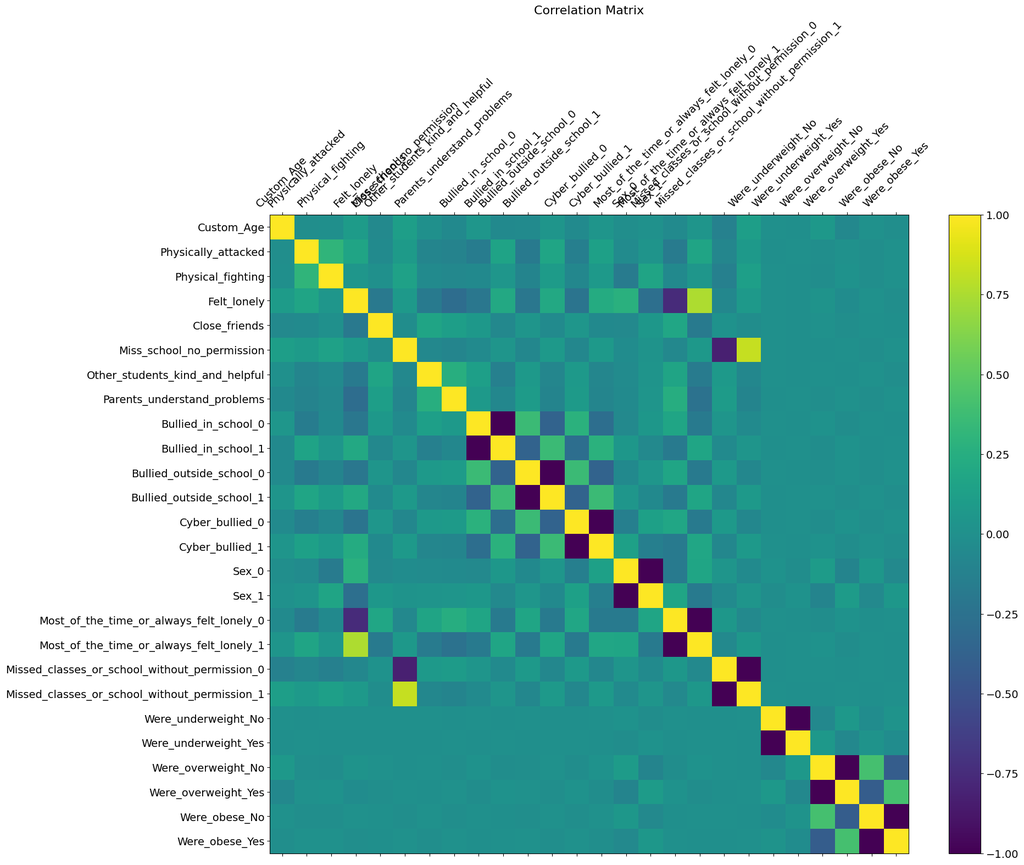

```python
import matplotlib.pyplot as plt

f = plt.figure(figsize=(19, 15))
plt.matshow(dataset.corr(), fignum=f.number)
plt.xticks(range(dataset.select_dtypes(['number']).shape[1]), dataset.select_dtypes(['number']).columns, fontsize=14, rotation=45)
plt.yticks(range(dataset.select_dtypes(['number']).shape[1]), dataset.select_dtypes(['number']).columns, fontsize=14)
cb = plt.colorbar()
cb.ax.tick_params(labelsize=14)
plt.title('Correlation Matrix', fontsize=16)
```

```python
correlation_matrix.style.background_gradient(cmap='coolwarm').format("{:.2f}")
```

|  | Custom_Age | Physically_attacked | Physical_fighting | Felt_lonely | Close_friends | Miss_school_no_permission | Other_students_kind_and_helpful | Parents_understand_problems | Bullied_in_school_0 | Bullied_in_school_1 | Bullied_outside_school_0 | Bullied_outside_school_1 | Cyber_bullied_0 | Cyber_bullied_1 | Sex_0 | Sex_1 | Most_of_the_time_or_always_felt_lonely_0 | Most_of_the_time_or_always_felt_lonely_1 | Missed_classes_or_school_without_permission_0 | Missed_classes_or_school_without_permission_1 | Were_underweight_No | Were_underweight_Yes | Were_overweight_No | Were_overweight_Yes | Were_obese_No | Were_obese_Yes |
| --- | --- | --- | --- | --- | --- | --- | --- | --- | --- | --- | --- | --- | --- | --- | --- | --- | --- | --- | --- | --- | --- | --- | --- | --- | --- | --- |
| Custom_Age | 1.00 | -0.01 | -0.00 | 0.10 | -0.06 | 0.12 | 0.01 | -0.05 | 0.05 | -0.05 | -0.04 | 0.04 | -0.04 | 0.04 | -0.01 | 0.01 | -0.04 | 0.04 | -0.12 | 0.12 | 0.01 | -0.01 | 0.07 | -0.07 | 0.01 | -0.01 |
| Physically_attacked | -0.01 | 1.00 | 0.31 | 0.17 | -0.05 | 0.09 | -0.09 | -0.10 | -0.16 | 0.16 | -0.18 | 0.18 | -0.14 | 0.14 | -0.04 | 0.04 | -0.17 | 0.17 | -0.08 | 0.08 | -0.00 | 0.00 | -0.01 | 0.01 | -0.01 | 0.01 |
| Physical_fighting | -0.00 | 0.31 | 1.00 | 0.05 | 0.00 | 0.15 | -0.05 | -0.07 | -0.05 | 0.05 | -0.10 | 0.10 | -0.08 | 0.08 | -0.17 | 0.17 | -0.05 | 0.05 | -0.13 | 0.13 | 0.00 | -0.00 | -0.02 | 0.02 | -0.01 | 0.01 |
| Felt_lonely | 0.10 | 0.17 | 0.05 | 1.00 | -0.19 | 0.08 | -0.18 | -0.29 | -0.20 | 0.20 | -0.21 | 0.21 | -0.23 | 0.23 | 0.27 | -0.27 | -0.75 | 0.75 | -0.07 | 0.07 | 0.00 | -0.00 | 0.03 | -0.03 | 0.01 | -0.01 |
| Close_friends | -0.06 | -0.05 | 0.00 | -0.19 | 1.00 | -0.02 | 0.17 | 0.12 | 0.07 | -0.07 | 0.04 | -0.04 | 0.05 | -0.05 | -0.05 | 0.05 | 0.18 | -0.18 | 0.02 | -0.02 | 0.00 | -0.00 | 0.01 | -0.01 | 0.01 | -0.01 |
| Miss_school_no_permission | 0.12 | 0.09 | 0.15 | 0.08 | -0.02 | 1.00 | -0.06 | -0.09 | -0.04 | 0.04 | -0.08 | 0.08 | -0.08 | 0.08 | -0.03 | 0.03 | -0.07 | 0.07 | -0.83 | 0.83 | 0.01 | -0.01 | -0.01 | 0.01 | -0.01 | 0.01 |
| Other_students_kind_and_helpful | 0.01 | -0.09 | -0.05 | -0.18 | 0.17 | -0.06 | 1.00 | 0.25 | 0.13 | -0.13 | 0.09 | -0.09 | 0.08 | -0.08 | -0.03 | 0.03 | 0.17 | -0.17 | 0.08 | -0.08 | 0.00 | -0.00 | 0.01 | -0.01 | 0.01 | -0.01 |
| Parents_understand_problems | -0.05 | -0.10 | -0.07 | -0.29 | 0.12 | -0.09 | 0.25 | 1.00 | 0.07 | -0.07 | 0.10 | -0.10 | 0.09 | -0.09 | -0.04 | 0.04 | 0.24 | -0.24 | 0.10 | -0.10 | -0.00 | 0.00 | -0.01 | 0.01 | -0.01 | 0.01 |
| Bullied_in_school_0 | 0.05 | -0.16 | -0.05 | -0.20 | 0.07 | -0.04 | 0.13 | 0.07 | 1.00 | -1.00 | 0.36 | -0.36 | 0.28 | -0.28 | -0.06 | 0.06 | 0.17 | -0.17 | 0.04 | -0.04 | 0.00 | -0.00 | 0.02 | -0.02 | 0.01 | -0.01 |
| Bullied_in_school_1 | -0.05 | 0.16 | 0.05 | 0.20 | -0.07 | 0.04 | -0.13 | -0.07 | -1.00 | 1.00 | -0.36 | 0.36 | -0.28 | 0.28 | 0.06 | -0.06 | -0.17 | 0.17 | -0.04 | 0.04 | -0.00 | 0.00 | -0.02 | 0.02 | -0.01 | 0.01 |
| Bullied_outside_school_0 | -0.04 | -0.18 | -0.10 | -0.21 | 0.04 | -0.08 | 0.09 | 0.10 | 0.36 | -0.36 | 1.00 | -1.00 | 0.36 | -0.36 | -0.05 | 0.05 | 0.17 | -0.17 | 0.08 | -0.08 | 0.00 | -0.00 | -0.01 | 0.01 | -0.01 | 0.01 |
| Bullied_outside_school_1 | 0.04 | 0.18 | 0.10 | 0.21 | -0.04 | 0.08 | -0.09 | -0.10 | -0.36 | 0.36 | -1.00 | 1.00 | -0.36 | 0.36 | 0.05 | -0.05 | -0.17 | 0.17 | -0.08 | 0.08 | -0.00 | 0.00 | 0.01 | -0.01 | 0.01 | -0.01 |
| Cyber_bullied_0 | -0.04 | -0.14 | -0.08 | -0.23 | 0.05 | -0.08 | 0.08 | 0.09 | 0.28 | -0.28 | 0.36 | -0.36 | 1.00 | -1.00 | -0.14 | 0.14 | 0.19 | -0.19 | 0.07 | -0.07 | -0.00 | 0.00 | -0.02 | 0.02 | -0.01 | 0.01 |
| Cyber_bullied_1 | 0.04 | 0.14 | 0.08 | 0.23 | -0.05 | 0.08 | -0.08 | -0.09 | -0.28 | 0.28 | -0.36 | 0.36 | -1.00 | 1.00 | 0.14 | -0.14 | -0.19 | 0.19 | -0.07 | 0.07 | 0.00 | -0.00 | 0.02 | -0.02 | 0.01 | -0.01 |
| Sex_0 | -0.01 | -0.04 | -0.17 | 0.27 | -0.05 | -0.03 | -0.03 | -0.04 | -0.06 | 0.06 | -0.05 | 0.05 | -0.14 | 0.14 | 1.00 | -1.00 | -0.17 | 0.17 | 0.04 | -0.04 | 0.02 | -0.02 | 0.09 | -0.09 | 0.06 | -0.06 |
| Sex_1 | 0.01 | 0.04 | 0.17 | -0.27 | 0.05 | 0.03 | 0.03 | 0.04 | 0.06 | -0.06 | 0.05 | -0.05 | 0.14 | -0.14 | -1.00 | 1.00 | 0.17 | -0.17 | -0.04 | 0.04 | -0.02 | 0.02 | -0.09 | 0.09 | -0.06 | 0.06 |
| Most_of_the_time_or_always_felt_lonely_0 | -0.04 | -0.17 | -0.05 | -0.75 | 0.18 | -0.07 | 0.17 | 0.24 | 0.17 | -0.17 | 0.17 | -0.17 | 0.19 | -0.19 | -0.17 | 0.17 | 1.00 | -1.00 | 0.06 | -0.06 | 0.01 | -0.01 | -0.02 | 0.02 | -0.00 | 0.00 |
| Most_of_the_time_or_always_felt_lonely_1 | 0.04 | 0.17 | 0.05 | 0.75 | -0.18 | 0.07 | -0.17 | -0.24 | -0.17 | 0.17 | -0.17 | 0.17 | -0.19 | 0.19 | 0.17 | -0.17 | -1.00 | 1.00 | -0.06 | 0.06 | -0.01 | 0.01 | 0.02 | -0.02 | 0.00 | -0.00 |
| Missed_classes_or_school_without_permission_0 | -0.12 | -0.08 | -0.13 | -0.07 | 0.02 | -0.83 | 0.08 | 0.10 | 0.04 | -0.04 | 0.08 | -0.08 | 0.07 | -0.07 | 0.04 | -0.04 | 0.06 | -0.06 | 1.00 | -1.00 | -0.01 | 0.01 | 0.00 | -0.00 | 0.00 | -0.00 |
| Missed_classes_or_school_without_permission_1 | 0.12 | 0.08 | 0.13 | 0.07 | -0.02 | 0.83 | -0.08 | -0.10 | -0.04 | 0.04 | -0.08 | 0.08 | -0.07 | 0.07 | -0.04 | 0.04 | -0.06 | 0.06 | -1.00 | 1.00 | 0.01 | -0.01 | -0.00 | 0.00 | -0.00 | 0.00 |
| Were_underweight_No | 0.01 | -0.00 | 0.00 | 0.00 | 0.00 | 0.01 | 0.00 | -0.00 | 0.00 | -0.00 | 0.00 | -0.00 | -0.00 | 0.00 | 0.02 | -0.02 | 0.01 | -0.01 | -0.01 | 0.01 | 1.00 | -1.00 | -0.07 | 0.07 | -0.03 | 0.03 |
| Were_underweight_Yes | -0.01 | 0.00 | -0.00 | -0.00 | -0.00 | -0.01 | -0.00 | 0.00 | -0.00 | 0.00 | -0.00 | 0.00 | 0.00 | -0.00 | -0.02 | 0.02 | -0.01 | 0.01 | 0.01 | -0.01 | -1.00 | 1.00 | 0.07 | -0.07 | 0.03 | -0.03 |
| Were_overweight_No | 0.07 | -0.01 | -0.02 | 0.03 | 0.01 | -0.01 | 0.01 | -0.01 | 0.02 | -0.02 | -0.01 | 0.01 | -0.02 | 0.02 | 0.09 | -0.09 | -0.02 | 0.02 | 0.00 | -0.00 | -0.07 | 0.07 | 1.00 | -1.00 | 0.41 | -0.41 |
| Were_overweight_Yes | -0.07 | 0.01 | 0.02 | -0.03 | -0.01 | 0.01 | -0.01 | 0.01 | -0.02 | 0.02 | 0.01 | -0.01 | 0.02 | -0.02 | -0.09 | 0.09 | 0.02 | -0.02 | -0.00 | 0.00 | 0.07 | -0.07 | -1.00 | 1.00 | -0.41 | 0.41 |
| Were_obese_No | 0.01 | -0.01 | -0.01 | 0.01 | 0.01 | -0.01 | 0.01 | -0.01 | 0.01 | -0.01 | -0.01 | 0.01 | -0.01 | 0.01 | 0.06 | -0.06 | -0.00 | 0.00 | 0.00 | -0.00 | -0.03 | 0.03 | 0.41 | -0.41 | 1.00 | -1.00 |
| Were_obese_Yes | -0.01 | 0.01 | 0.01 | -0.01 | -0.01 | 0.01 | -0.01 | 0.01 | -0.01 | 0.01 | 0.01 | -0.01 | 0.01 | -0.01 | -0.06 | 0.06 | 0.00 | -0.00 | -0.00 | 0.00 | 0.03 | -0.03 | -0.41 | 0.41 | -1.00 | 1.00 |

```python
# For instance, printing highly correlated pairs above a certain threshold:
threshold = 0.3
high_corr_pairs = []
for i in range(len(correlation_matrix.columns)):
    for j in range(i + 1, len(correlation_matrix.columns)):
        if abs(correlation_matrix.iloc[i, j]) > threshold and abs(correlation_matrix.iloc[i, j]) < 0.9999:
            high_corr_pairs.append((correlation_matrix.columns[i], correlation_matrix.columns[j], correlation_matrix.iloc[i, j]))
print("Highly correlated feature pairs:")
for pair in high_corr_pairs:
    print(f"{pair[0]} - {pair[1]} : {pair[2]}")
```

```
Highly correlated feature pairs:
Physically_attacked - Physical_fighting : 0.31118076041305215
Felt_lonely - Most_of_the_time_or_always_felt_lonely_0 : -0.7520065082286882
Felt_lonely - Most_of_the_time_or_always_felt_lonely_1 : 0.7520065082286881
Miss_school_no_permission - Missed_classes_or_school_without_permission_0 : -0.8253534399187106
Miss_school_no_permission - Missed_classes_or_school_without_permission_1 : 0.8253534399187105
Bullied_in_school_0 - Bullied_outside_school_0 : 0.36148056949387813
Bullied_in_school_0 - Bullied_outside_school_1 : -0.3614805694938789
Bullied_in_school_1 - Bullied_outside_school_0 : -0.3614805694938787
Bullied_in_school_1 - Bullied_outside_school_1 : 0.3614805694938795
Bullied_outside_school_0 - Cyber_bullied_0 : 0.3605338800400113
Bullied_outside_school_0 - Cyber_bullied_1 : -0.36053388004001097
Bullied_outside_school_1 - Cyber_bullied_0 : -0.36053388004001174
Bullied_outside_school_1 - Cyber_bullied_1 : 0.3605338800400116
Were_overweight_No - Were_obese_No : 0.4095422275941285
Were_overweight_No - Were_obese_Yes : -0.4095422275941284
Were_overweight_Yes - Were_obese_No : -0.40954222759412806
Were_overweight_Yes - Were_obese_Yes : 0.40954222759412817
```

```python
from sklearn.cluster import KMeans
from sklearn.metrics import silhouette_score

# Select the most correlated features
selected_features = ['Bullied_in_school_1', 'Bullied_in_school_0', 'Bullied_outside_school_1', 'Bullied_outside_school_0', 'Cyber_bullied_1',
                     'Cyber_bullied_0', 'Most_of_the_time_or_always_felt_lonely_1', 'Most_of_the_time_or_always_felt_lonely_0',
                     'Felt_lonely', 'Missed_classes_or_school_without_permission_1', 'Missed_classes_or_school_without_permission_0',
                     'Miss_school_no_permission', 'Were_overweight_Yes', 'Were_overweight_No', 'Were_obese_Yes', 'Were_obese_No']

# Create a new dataframe with the selected features
selected_df = dataset[selected_features]

# Perform clustering using K-means

kmeans = KMeans(n_clusters=3, random_state=0)
clusters = kmeans.fit_predict(selected_df)

# Add the cluster labels to the dataframe
selected_df['Cluster'] = clusters

# Print the dataframe with cluster labels
print(selected_df)
# Calculate the silhouette score
silhouette_avg = silhouette_score(selected_df, clusters)

# Print the silhouette score
print("The average silhouette score is:", silhouette_avg)
```

```
        Bullied_in_school_1  Bullied_in_school_0  Bullied_outside_school_1  \
record
2                         0                    1                         0
3                         0                    1                         0
5                         0                    1                         0
6                         0                    1                         0
7                         0                    1                         0
...                     ...                  ...                       ...
57091                     0                    1                         1
57092                     0                    1                         0
57093                     0                    1                         0
57094                     0                    1                         1
57095                     0                    1                         1

        Bullied_outside_school_0  Cyber_bullied_1  Cyber_bullied_0  \
```

[output cut: 99 more lines]

[output not shown]

[output cut: 33 more lines]

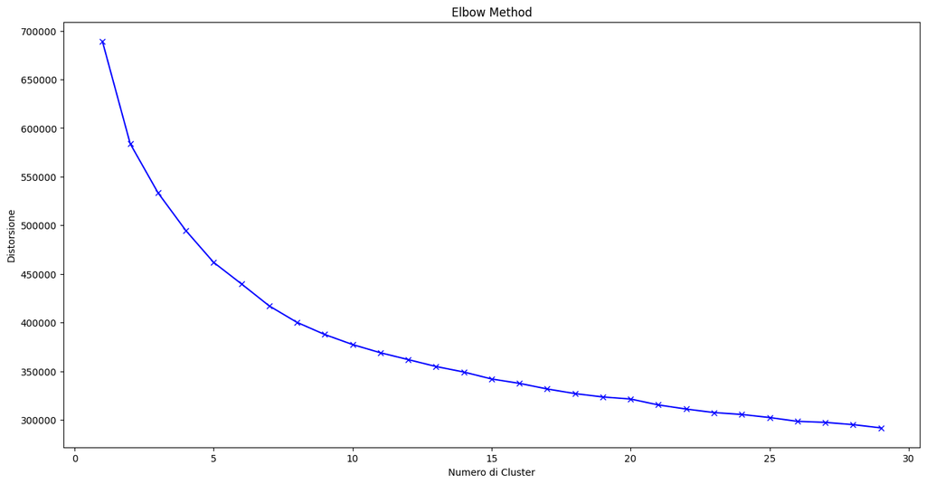

```python
distorsions = []
K = range(1, 30)
for k in K:
    kmeans = KMeans(n_clusters=k)
    kmeans.fit(dataset)
    distorsions.append(kmeans.inertia_)

plt.figure(figsize=(16,8))
plt.plot(K, distorsions, 'bx-')
plt.xlabel('Numero di Cluster')
plt.ylabel('Distorsione')
plt.title('Elbow Method')
plt.show()
```